# ESM 232 Assignment 4

Claire Madden & Lydia Bleifuss

5/15/2020

```r
#Load the packages
library(tidyverse)
library(deSolve)
library(sensitivity)
```

Consider the following model of forest growth (where forest size in measured in units of carbon (C))

dC/dt = 0 when air temperatures are below 0

dC/dt = r*C for forests where carbon is below a canopy closure threshold

dC/dt = g. for forests where carbon is above the threshold canopy closure

dC/dt = 0 once carrying capacity is reached.

The size of the forest (C), Canopy closure threshold and carrying capacity are all in units of carbon

You could think of the canopy closure threshold as the size of the forest at which growth rates change from exponential to linear

You can think of r, as early exponential growth rate and g and the linear growth rate

1. Implement this model in R (as a differential equation)

```r
source("../R/dynamic_model.R")
```

2a. Run the model for 300 years (using the ODE solver) starting with an initial forest size of 10 kg/C, and using the following parameters

canopy closure threshold of 100 kgC - canopy

a carrying capacity of 500 kg C - carry

a early growth rate of 0.01 - r

a later growth rate of 2 kg/year - g

an air temperature of 20C - temp

```r
# set parameters
C <- 10
years <- seq(from=1, to=300, by=1)
canopy <- 100
carry <- 500
r <- 0.01
g <- 2
temp <- 20

parms = list(canopy = 100, carry = 500, r = 0.01, g = 2, temp = 20)

results = ode(y=C, times = years, func=forestgrowth, parms=parms)

head(results)
```

```
##      time        1
## [1,]    1 10.00000
## [2,]    2 10.10050
## [3,]    3 10.20202
## [4,]    4 10.30455
## [5,]    5 10.40811
## [6,]    6 10.51271
```

```r
colnames(results) = c("Year", "KgC")
```

2b. Graph the results

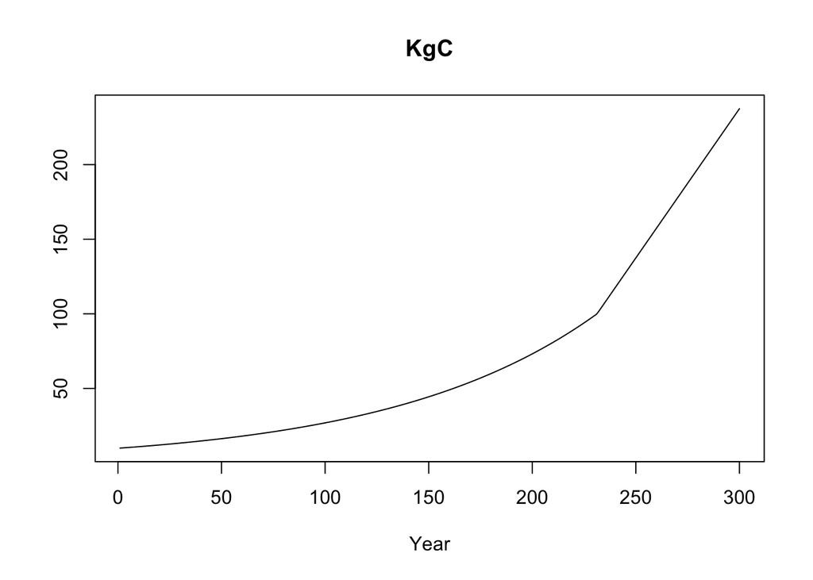

```r
plot(results)
```

```r
# SOBEL

np=1000

# generate two examples of random number from parmeter distributions

r_s = rnorm(mean = 0.01, sd = 0.001, n=np)
g_s = rnorm(mean = 2, sd = 0.1, n=np)

# Sample 1

X1 = cbind.data.frame(r_s,g_s)

r_s = rnorm(mean = 0.01, sd = 0.001, n=np)
g_s = rnorm(mean = 2, sd = 0.1, n=np)

# Sample 2

X2 = cbind.data.frame(r_s,g_s)


sens1_sobel = sobol2007(model = NULL, X1, X2, nboot = 200)


parms_sobel <- list(r = sens1_sobel$X$r_s[1],
              g = sens1_sobel$X$g_s[1],
              canopy = 100,
              carry = 500,
              temp = 20)


results_sobel = ode(y=C, times = years, func=forestgrowth, parms=parms_sobel)


head(results_sobel)
```

```
##      time  1
## [1,]    1 10
## [2,]    2 12
## [3,]    3 14
## [4,]    4 16
## [5,]    5 18
## [6,]    6 20
```

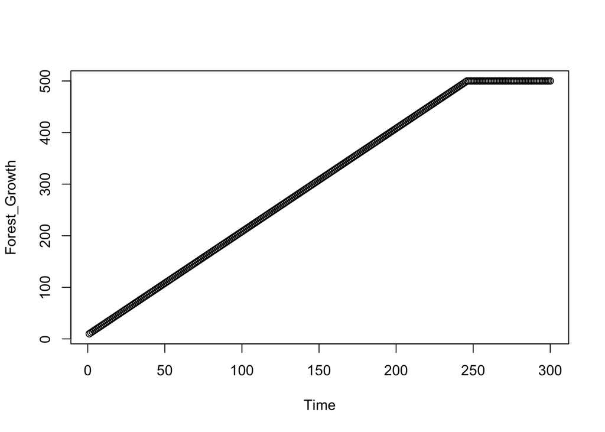

```r
colnames(results_sobel) = c("Time", "Forest_Growth")

results_sobel = as.data.frame(results_sobel)

plot(results_sobel)
```

```r
#Run sensitivity: It appears that our ode was only running with our first two values of r and g. Need to use mapply?

# sensitivity_sobel = sensitivity::tell(sens1_sobel,results_sobel, results_sobel.names="ga")


# first-order indices (main effect without co-variance)
# sens1_sobel$S

# total sensitivity index -note that this partitions the output variance - so values sum to 1
# sens1_sobel$T

# The difference between the main effect and total effect can tell us something about how the parameter influences results
# so in the main effect we include interactions with other parameters

# print(sens1_sobel)
# plot(sens1_sobel)
```

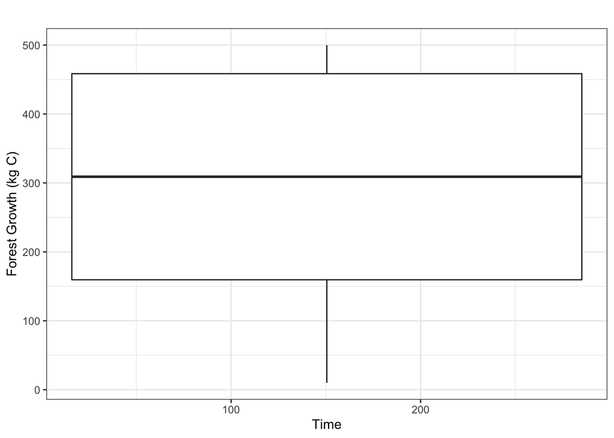

```r
plot_sobel <- ggplot(data = results_sobel, aes(x = Time, y = Forest_Growth))+
  geom_boxplot()+
  labs(x = "Time",
       y = "Forest Growth (kg C)",
       title = "")+
  theme_bw()


plot_sobel
```

Submit R markdown with model implementation, graphs and sensitivity analysis and R file with your model:

Hi Rachel!

We are not sure where we are going wrong and are having trouble applying what we have gone over in class to this assignmnet. We felt our code sluthing energy would be better directed to digging into our class project, which we are excited for! Would love to hear your feedback on what we could have done differently in this code.

Thanks! - Lydia & Claire